# Decision trees

**Taotao Tan**

## Sklearn

The package we will be using to perform decision trees is called `Sklearn`. In this package, the important function is called `sklearn.tree.DecisionTreeClassifier` & `sklearn.tree.DecisionTreeRegressor` to perform a cart analysis. CART stands for Classification and Regression Test. The package is capable of taking continuous variables and using them for classification and regression.

```python
import sklearn.metrics as metrics
import numpy as np
import pandas as pd
from matplotlib import pyplot as plt
from sklearn import tree
from sklearn.metrics import confusion_matrix
from sklearn.model_selection import train_test_split
from sklearn.tree import DecisionTreeClassifier
```

The dataset we will testing our code is the same that we have used in the past. It is a dataset where alive status is the output variable, where 1 means dead and 0 means alive. The variables are measurements of breast tumors and some markers.

```python
data = pd.read_csv("all.15k.patients.txt",sep = "\t")
data.head()
```

|  | dateofbirth | maritalstatus | race | ageatdiagnosis | alivestatus | survivaltime | grade | nodesexam | nodespos | extent | nodalstatus | size | pgr | er |
| --- | --- | --- | --- | --- | --- | --- | --- | --- | --- | --- | --- | --- | --- | --- |
| pid00001 | 28/01/1932 | 5 | 2 | 61 | 0 | 110 | 3 | 32 | 3 | 10 | 6 | 60 | 2 | 2 |
| pid00002 | 07/05/1934 | 2 | 3 | 60 | 0 | 100 | 2 | 13 | 1 | 10 | 6 | 15 | 1 | 1 |
| pid00003 | 14/04/1921 | 5 | 3 | 76 | 0 | 70 | 3 | 8 | 0 | 10 | 0 | 8 | 1 | 1 |
| pid00004 | 08/11/1931 | 3 | 3 | 61 | 1 | 31 | 3 | 20 | 0 | 10 | 0 | 10 | 2 | 2 |
| pid00005 | 08/01/1922 | 2 | 3 | 74 | 1 | 47 | 2 | 16 | 8 | 10 | 6 | 15 | 2 | 1 |

First we will make sure to treate all our variables as categorical variables except for size and nodespos.

```python
data["alivestatus"] = pd.Categorical(data.alivestatus)
data["grade"] = pd.Categorical(data.grade)
data["nodespos"] = pd.to_numeric(data.nodespos)
```

In order to create a decision tree model, we will call function `sklearn.tree.DecisionTreeClassifier`

```python
# represent data in numpy array
X = np.array(data[["grade","nodespos", "size"]])
y = np.array(data.alivestatus)


# define the classification tree
clf = DecisionTreeClassifier().fit(X,y)
```

As always, we will first test, using the same dataset as the training set, to see how well the model worked. This obvoiusly is not a fair assesment, but we expect this to give us the best predictions possible.

```python
results = clf.predict(X)
confusion_matrix(results, y)
```

```
array([[12026,  1767],
       [  219,   988]])
```

We can also plot this decision tree

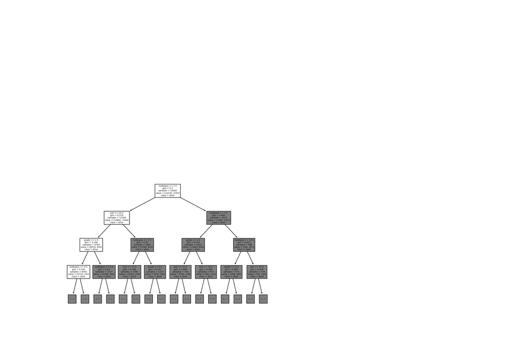

```python
%matplotlib notebook
plt.figure(figsize=(18,12))
plot = tree.plot_tree(clf,feature_names = ["grade","nodespos", "size"],
                      class_names = ["alive", "dead"], max_depth = 3)
plt.show()
```

## AUC

To evaluate our models, letâs calculate the AUC. The default result of the predict function is the actual prediction of the state. However we can also ask for the probabilities of the calls, which will help us create the AUC curves.

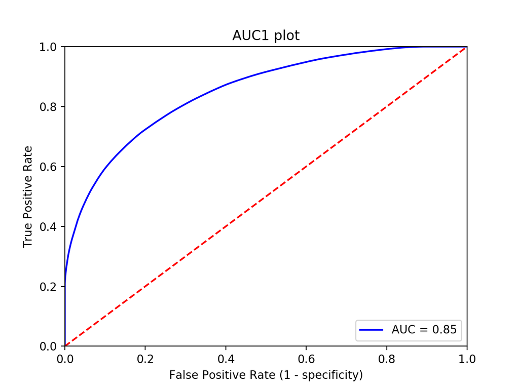

```python
%matplotlib notebook
# calculate the fpr and tpr for all thresholds of the classification
probs = clf.predict_proba(X)
preds = probs[:,1]
fpr, tpr, threshold = metrics.roc_curve(y, preds)
roc_auc = metrics.auc(fpr, tpr)

# method I: plt
plt.figure()

plt.title('AUC1 plot')
plt.plot(fpr, tpr, 'b', label = 'AUC = %0.2f' % roc_auc)
plt.legend(loc = 'lower right')
plt.plot([0, 1], [0, 1],'r--')
plt.xlim([0, 1])
plt.ylim([0, 1])
plt.ylabel('True Positive Rate')
plt.xlabel('False Positive Rate (1 - specificity)')
plt.show()
```

### Tuning hyperparameters, set max_depth = 2

```python
# define the classification tree
clf2 = DecisionTreeClassifier(max_depth=2).fit(X,y)
```

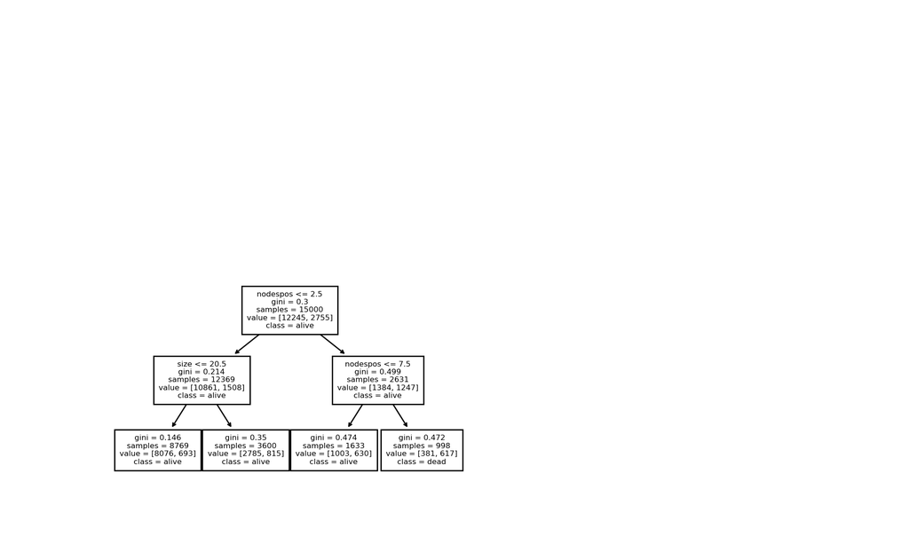

```python
%matplotlib notebook
plt.figure(figsize=(10,6))
plot = tree.plot_tree(clf2,feature_names = ["grade","nodespos", "size"],
                      class_names = ["alive", "dead"], fontsize=6)
plt.show()
```

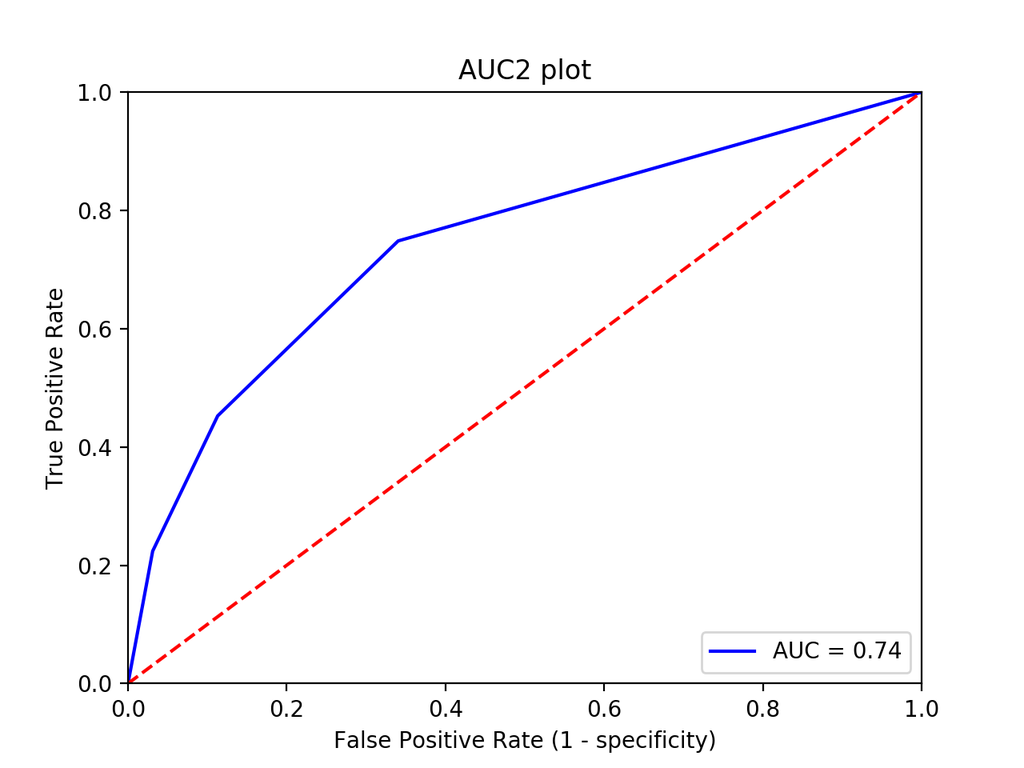

```python
# calculate the fpr and tpr for all thresholds of the classification
probs2 = clf2.predict_proba(X)
preds2 = probs2[:,1]
fpr2, tpr2, threshold2 = metrics.roc_curve(y, preds2)
roc_auc2 = metrics.auc(fpr2, tpr2)

# method I: plt
plt.figure()

plt.title('AUC2 plot')
plt.plot(fpr2, tpr2, 'b', label = 'AUC = %0.2f' % roc_auc2)
plt.legend(loc = 'lower right')
plt.plot([0, 1], [0, 1],'r--')
plt.xlim([0, 1])
plt.ylim([0, 1])
plt.ylabel('True Positive Rate')
plt.xlabel('False Positive Rate (1 - specificity)')
plt.show()
```

## Leave Out test

As we have learned in class, it is not the best idea to use the same dataset to train and test the dataset. So for this example we will use the same leave out method as applied in the Logistic Regression section

```python
X_train, X_test, y_train, y_test = train_test_split(X, y, test_size=0.3, random_state=42)
```

```python
# define the classification tree
clf3 = DecisionTreeClassifier(max_depth=2).fit(X_train,y_train)
```

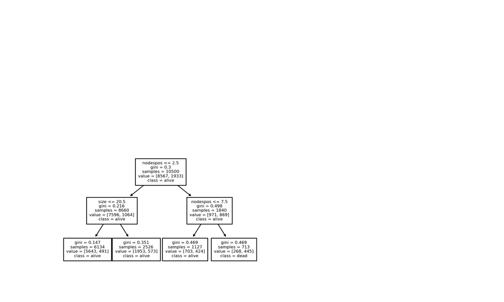

```python
%matplotlib notebook
plt.figure(figsize=(10,6))
plot = tree.plot_tree(clf3,feature_names = ["grade","nodespos", "size"],
                      class_names = ["alive", "dead"], fontsize=6)
plt.show()
```

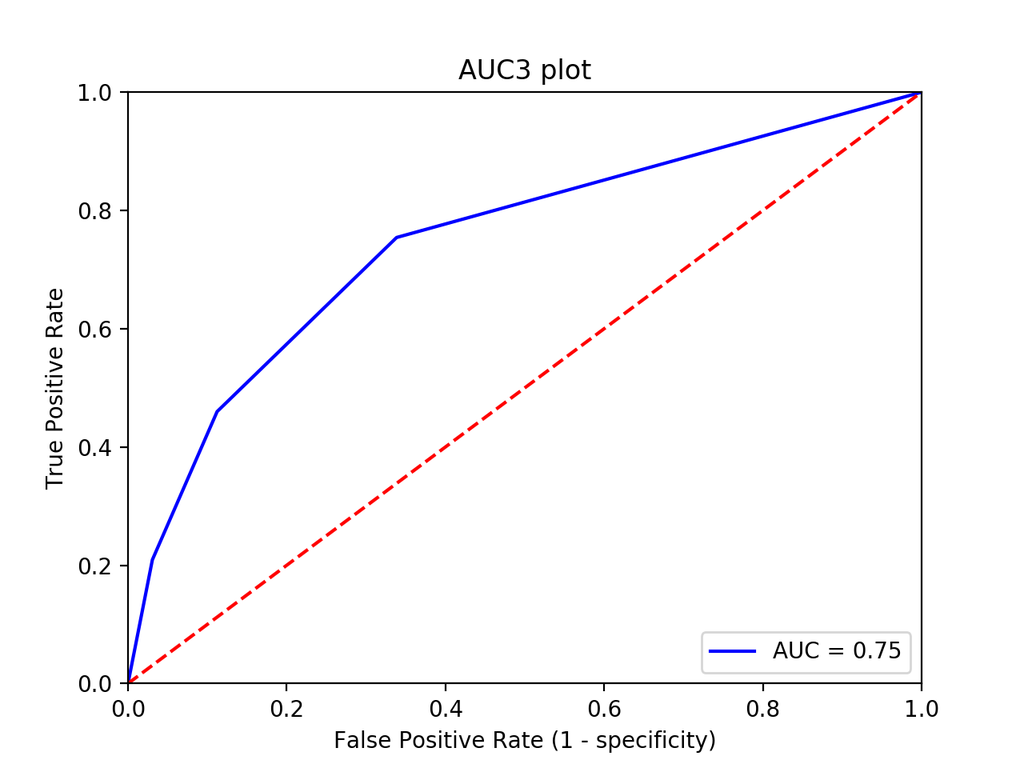

```python
%matplotlib notebook
# calculate the fpr and tpr for all thresholds of the classification
probs3 = clf3.predict_proba(X_test)
preds3 = probs3[:,1]
fpr3, tpr3, threshold3 = metrics.roc_curve(y_test, preds3)
roc_auc3 = metrics.auc(fpr3, tpr3)

# method I: plt
plt.figure()

plt.title('AUC3 plot')
plt.plot(fpr3, tpr3, 'b', label = 'AUC = %0.2f' % roc_auc3)
plt.legend(loc = 'lower right')
plt.plot([0, 1], [0, 1],'r--')
plt.xlim([0, 1])
plt.ylim([0, 1])
plt.ylabel('True Positive Rate')
plt.xlabel('False Positive Rate (1 - specificity)')
plt.show()
```

Because the AUC of the two tests ( one using the same test dataset as training set and the other using different data for training and testing) are very close, tells us that our model is not over-fitting.